# Summary Plots and Statistics for HICEAS 2017 Odontocete Events

Summary tables and plots to aid in manual assessment of potential false killer whale events in datasets without visual confirmation; this report is meant to provide an example of how visually verified events would look

Selene Fregosi

19 May 2024

## HICEAS 2017 towed array data: Lasker - 2017_HICEAS_1705_ch5.rdata

Summaries generated: 2024 May 19 00:35 UTC

Cruise 1705 = Lasker

Cruise 1706 = Sette

### Setup

Load needed libraries.

```r
# load all libraries
devtools::install_github('taikisan21/PAMpal')
library(PAMpal)
# library(kableExtra) # known bug with R ver 4.3.0 so install from github
# devtools::install_github('kupietz/kableExtra')
library(kableExtra)
library(ggplot2)
library(RSQLite)
library(tuneR)
library(here)

# I don't think we need these but saving here in case
# library(dplyr)
# library(tcltk)
# library(manipulate)
```

Set user-defined variables.

```r
# name project
ProjID <- 'HICEAS 2017'

# define subfolder paths to and binaries and database files
path_to_binaries <- file.path(params$path_pg, 'Binaries', params$ship)
path_to_db <- file.path(params$path_pg, 'Database')

# path to AcousticStudy files - ship specific
if (params$ship == 'Lasker'){
  detsFile <- file.path(params$path_acSt, '2017_HICEAS_1705_ch5.rdata')
} else if (params$ship == 'Sette'){
  detsFile <- file.path(params$path_acSt, '2017_HICEAS_1706_ch5.rdata')
}

# set path to reference spectra if will be used
path_to_refSpec <- file.path(params$path_to_refSpec) # pull from YAML
# specify which reference spectra to plot
# refSpecList = c('Gm', 'Pc')
refSpecList <- params$refSpecList # pull from YAML
refSpecSp <- params$refSpecSp

# set up datebase driver
sqlite <- dbDriver("SQLite")

#Set time zone to UTC
Sys.setenv(TZ = 'UTC')

# reference spectra colors - allows for up to 6 ref specs
# pastel
# rsPalette <- c('#66c2a5', '#fc8d62', '#8da0cb', '#e78ac3',
#                '#a6d854', '#ffd92f')
# bold
rsPalette <- c('#1b9e77', '#d95f02', '#7570b3', '#e7298a',
               '#66a61e', '#e6ab02')
```

#### Define needed functions

Source some external functions

```r
source(here('R', 'functions', 'filterClicks.R'))
source(here('R', 'functions', 'loadMultiBinaries.R'))
source(here('R', 'functions', 'plotContours.R'))
source(here('R', 'functions', 'clickSummary.R'))
source(here('R', 'functions', 'whistleSummary.R'))

# if not using Rproj/here package use:
# source(file.path(params$path_code, 'R', 'functions', 'loadMultiBinaries.R'))
```

#### Load and prep AcousticStudies

Load existing PAMpal AcousticStudy object for event processing. They were saved as .RDS files so must be read in with `readRDS` rather than `load`.

These were not filtered, so will need to be filtered using `filterClicks`.

```r
# load existing AcousticStudy
detsAll <- readRDS(detsFile)
# cat('Loaded', detsFile, '\n')

# summarize how many events
nEventsAll <- length(names(events(detsAll)))
# cat(nEventsAll, 'original events\n')

spCodes <- c('31', '32', '33', '36', '37')
bfList <- list()
for (sp in 1:length(spCodes)){
  spCode <- spCodes[sp]
  bfList[[sp]] <- filter(detsAll, species == spCode)
}
dets <- bindStudies(bfList)

nEvents <- length(names(events(dets)))
# cat(nEvents, 'single species blackfish events\n')

# these files will NOT have the correct binary paths so have to update them
# (this is slow...)
dets <- PAMpal::updateFiles(dets, bin = path_to_binaries, db = path_to_db)

# filter AcousticStudy
detsFilt <- filterClicks(dets)

# number of events may change after filtering (all clicks may be filtered out)
nEventsFilt <- length(names(events(detsFilt)))

# cat(nEventsFilt, 'filtered, single species blackfish events\n')
```

Loaded //piccrpnas/crp2/McCullough/PAMpal/Acoustic_Studies/2017_HICEAS_1705_ch5.rdata, filtered AcousticStudy to only blackfish events and cleaned up bad click detections:

**338 events** total for all species, **15 events** for blackfish only, and **15 events** after filtering.

#### Load reference spectra, if specified

Load the reference spectra for plotting, if set with `refSpecList`.

```r
# refSpecList is specified in YAML params. Can be one or multiple species
# for single species specify as char string without quotations e.g., refSpecPc
# for multiple species, specify with call to R and c()
#     e.g., !r c('meanSpecGm', 'refSpecPc_LLHARP')

if (!is.null(refSpecList)){
  refSpecs = list()
  for (rs in refSpecList){
    refSpecs[[rs]] = read.csv(file.path(path_to_refSpec, paste0(rs, '.csv')))
  }
}
```

### Event summaries

Loop through each detection event (n = 15) and process/filter detected clicks, create plots, and calculate summary statistics. This step works at two levels - on the level of an AcousticStudy object, and on a data.frame of extracted click data from that AcousticStudy object.

```r
for (iEvent in c(1:nEventsFilt)){
  # iEvent = 6 # for testing
  # ("pagebreak \n")

  # extract this event UID string
  eventList <- events(detsFilt)
  eventUID <- names(eventList)[iEvent]

  # set header for this event and print time
  cat('\n\n#### Event ID:   ', names(eventList)[iEvent], '  |   Species:   ',
      eventList[[iEvent]]@species$id, '\n')
  cat('Time:   ', format(eventList[[eventUID]]@ancillary$grouping$start,
                         '%Y-%m-%d %H:%M%Z'), ' to ',
      format(eventList[[eventUID]]@ancillary$grouping$end, '%Y-%m-%d %H:%M%Z'),
      '\n')

  ###### summarize clicks ######
  cl <- clickSummary(detsFilt, eventUID)

  cat('\nEvent contains ', nrow(getClickData(dets[[eventUID]])),
      ' original clicks,', paste0('**', cl$nClicks), 'valid clicks** after',
      'filtering.\n')
  cat('\n')

  ###### summarize whistles ######
  wl <- whistleSummary(detsFilt, eventUID)

  cat('\nEvent contains', paste0('**', wl$nWhistles), 'whistles**.\n')
  cat('\n')

  ###### click plots and table ######

  cat('\n##### Click plots and table\n')
  cat('\n SNR histogram includes all filtered clicks. Other plots contain only',
      'clicks with SNR >= 15 dB', paste0('(**n = ', cl$nGoodClicks, ' clicks**)'),
      '.\n')
  cat('\n')

    # if any clicks...
  if (cl$nClicks > 0){
    # histogram of all clicks and SNR >= 15 dB cut off
    xMax <- max(c(15, ceiling(max(cl$snr)) + 2)) # whichever is bigger
    hist(cl$snr, breaks = seq(from = floor(min(cl$snr)),
                              to = xMax, by = 2),
         main = 'Click SNR', sub = '(all filtered clicks)', xlab = 'SNR')
    abline(v = 15, lty = 2, lwd = 2, col = 'red4')

  }

    # if sufficient good clicks...
  if (cl$nGoodClicks > 0) {
    # histogram of click durations - good clicks only
    subStr <- paste0('(high SNR clicks, n=', cl$nGoodClicks, ')')
    hist(cl$goodClicks$duration,
         breaks = seq(from = 0, to = max(cl$goodClicks$duration) + 100,
                      by = 100), main = 'Click duration', sub = subStr,
         xlab = expression(paste('duration [', mu, 's]')))
    abline(v = median(cl$goodClicks$duration), lty = 2, lwd = 2, col = 'black')
    legend('topright', legend = 'median', lty = 2, lwd = 2, col = 'black')


    cat('\n')
    cat('\n')


    # Calculate and plot Concatenated and Mean Spectrum for clicks w/ max SNR > 15dB
    # NB: JLKM uses more exaggerated SNR (>40 dB) for BWs bc actual spectra may
    # be noisy for single clicks
    # reducing wl can give more accurate noise floor but 'smoother' spectrum
    # increasing wl will give more exact spectrum but may exclude too many
    # clicks based on SNR (noise measure will overlap with click output; noise
    # is just measured as same wl from start of binary snippet and binaries
    # binary snippets are v short)
    # Trial and error - 256 works ok for LLHARP data = 1.28 ms
    # NB: JLKM uses 500 for beaked whales with samp rate 288k
    avgSpec <- calculateAverageSpectra(detsFilt, evNum = eventUID, wl = 256,
                                       channel = 1, norm = TRUE, noise = TRUE,
                                       sort = TRUE, snr = 15, flim = c(0, 100000),
                                       plot = c(TRUE, FALSE))
    # concatonated spectrogram will get plotted within calculation

    # avg spectrum plots separately (bc adding stuff)
    if (!is.null(avgSpec)) {
      # Peak freq as calculated by calculateAvgerageSpectra -for subtitle
      peakFreq <- round(avgSpec$freq[which.max(avgSpec$avgSpec)]/1000, 2)

      plot(1, type = 'n', xlim = c(0, 100), ylim = c(min(avgSpec$avgSpec), 0),
           xlab = 'Frequency (kHz)', ylab = 'Normalized Magnitude (dB)',
           main = 'Average Spectrum', sub = paste0('Peak: ', peakFreq, 'kHz'))
      # add grid lines for frequency at 10 kHz intervals
      for (iline in ((0:15)*10)) {lines(c(iline,iline), c(-60,10), col="gray")}
      # add template spectra
      if (length(refSpecs) > 0){
        rsCols <- rsPalette[1:length(refSpecs)]
        for (rs in 1:length(refSpecs)){
          rsTmp <- refSpecList[rs]
          rsNorm <- refSpecs[[rsTmp]]
          rsMax <- max(rsNorm$dB)
          rsNorm$dBNorm <- rsNorm$dB - rsMax
          lines(rsNorm$frq, rsNorm$dBNorm, col = rsCols[rs], lwd = 2)
        }
      }

      # plot noise
      lines(avgSpec$freq/1000, avgSpec$avgNoise, lty = 3, lwd = 2)
      # plot avg spectrum
      lines(avgSpec$freq/1000, avgSpec$avgSpec, lty = 2, lwd = 3)
      # also plot median spectrum
      medSpec <- 20*log10(apply(avgSpec$allSpec, 1, function(y) {
        median(10^(y/20), na.rm = TRUE)}))
      medSpecNorm <- medSpec - max(medSpec, na.rm = TRUE)
      lines(avgSpec$freq/1000, medSpecNorm, lty = 1, lwd = 3)

      # add legend
      legend(x = 'topright', c(refSpecSp, 'Avg.', 'Med.', 'Noise'),
             lty = c(rep(1, length(refSpecs)), 2, 1, 3),
             lwd = c(rep(1, length(refSpecs)), 2, 3, 2),
             col = c(rsCols, 'black', 'black', 'black'), cex = 0.8)
    }


    # NB: JLKM BW approach has additional plots here:
    # IPI
    # Waveform of strongest click
    # Wigner plot
    # We are not including those here because not really useful for FKW, but if
    # interested in adding back in, see:
    #       https://github.com/jlkeating/PAMGuard_Event_Code


    cat('\n')
    cat('\n')


    # create median stats table for clicks with -15 dB TK noise cut off
    cat('\n\n Median statistics for', cl$nGoodClicks, 'high SNR clicks with',
        'SNR >= 15 dB.')
    cat('\n')

    cat(knitr::kable(cl$mt, format = 'html', caption = '', align = 'l',
                     row.names = FALSE) %>%
          kable_styling(bootstrap_options = c('basic', 'condensed'),
                        full_width = F))

  }  else { # no good clicks so no summary plots/table
    cat('\nNo clicks of sufficient SNR to plot.\n')
  }


  ###### whistle plots and table ######

  cat('\n##### Whistle plots and table\n')

  # if whistles present ...
  if (wl$nWhistles > 0) {
    # create median stats table for all whistles
    # cat('\n\n Median statistics for', wl$nWhistles, 'whistles.')
    # cat('\n')

    # plot whistle contours
    # map the needed binary files
    binFiles <- dets@events[[eventUID]]@files$binaries
    wmFileIdx <- grep(pattern = '^.*WhistlesMoans_Whistle_and_Moan.*\\.pgdf$',
                      binFiles)
    wmFiles <- dets@events[[eventUID]]@files$binaries[wmFileIdx]

    # load them
    whBin <- loadMultiBinaries(wmFiles)
    # trim to just the event time
    whBinEv <- whBin[names(whBin) %in%
                       detsFilt[[eventUID]]$Whistle_and_Moan_Detector$UID]

    # #plot - ggplot version/functionized
    # pc <- plotContours(whBinEv)
    # # print(pc)
    # pc + ggtitle(eventUID)
    #

    # get plot limits
    # xMax <- 0
    # yMax <- 0
    # for (wc in 1:length(names(whBinEv))){
    #   df <- data.frame(time = whBinEv[[wc]]$time - whBinEv[[wc]]$time[1],
    #                    freq = whBinEv[[wc]]$freq/1000)
    #   xMaxTmp <- max(df$time)
    #   yMaxTmp <- max(df$freq)
    #   if (xMaxTmp > xMax){xMax <- xMaxTmp}
    #   if (yMaxTmp > yMax){yMax <- yMaxTmp}
    # }
    # or use standard max lims
    xMax <- 1.5
    yMax <- 20

    # plot each line
    plot(1, type = 'n', xlim = c(0, round(xMax,2)), ylim = c(0, round(yMax,-1)),
         xlab = 'Time (s)', ylab = 'Frequency (kHz)',
         main = 'Whistle Contours')
    # add grid lines for frequency at 0.125 s and 5 kHz intervals
    for (iline in (seq(0,2,0.125))) {lines(c(iline,iline), c(-10,60),
                                           col="lightgray")}
    for (iline in (seq(0,50,5))) {lines(c(-0.5,2.5), c(iline,iline),
                                        col="lightgray")}
    # loop through each contour
    for (wc in 1:length(names(whBinEv))){
      df <- data.frame(time = whBinEv[[wc]]$time - whBinEv[[wc]]$time[1],
                       freq = whBinEv[[wc]]$freq/1000)
      lines(df$time, df$freq, col = rgb(0,0,0,0.4))
    }

    # plot histogram of median frequency
    hist(wl$wh$freqMedian/1000,
         breaks = seq(0, ceiling(max(wl$wh$freqMedian/1000)) + 1, 1),
         main = 'Histogram of whistle median frequency',
         xlab = 'Median frequency (kHz)')

    cat('\n')
    cat('\n')

    cat('Median statistics for n = ', wl$nWhistles, 'whistles.\n')
    # create median stats table for all whistles
    cat(knitr::kable(wl$mt, format = 'html', caption = '', align = 'l',
                     row.names = FALSE) %>%
          kable_styling(bootstrap_options = c('basic', 'condensed'),
                        full_width = F))

  } else {
    cat('\nNo whistles present.\n')
  }

  cat('\n')
  cat('\n\n --- \n\n')
  cat('\n')

}
```

#### Event ID: 1705086 | Species: 32

Time: 2017-09-02 20:46UTC to 2017-09-02 21:13UTC

Event contains 6496 original clicks, **230 valid clicks** after filtering.

Event contains **2 whistles**.

##### Click plots and table

SNR histogram includes all filtered clicks. Other plots contain only clicks with SNR >= 15 dB (**n = 198 clicks**) .

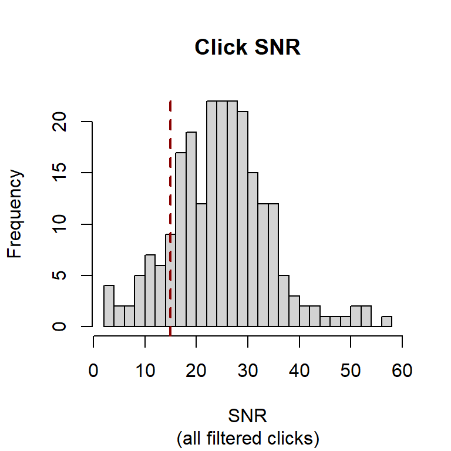

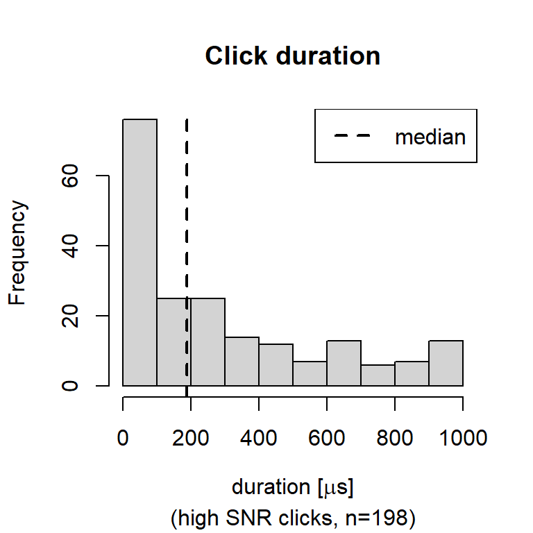

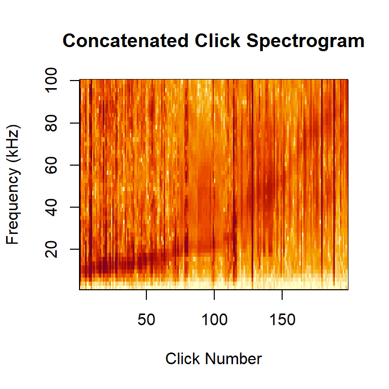

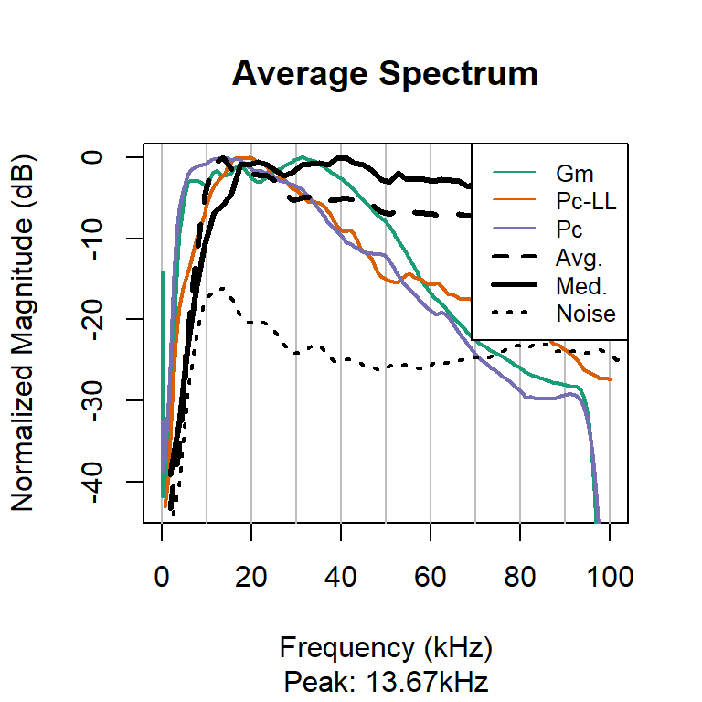

Median statistics for 198 high SNR clicks with SNR >= 15 dB.

| parameter | value |
| --- | --- |
| Median Peak Frequency [kHz] | 19.2 |
| Median 3dB Center Frequency [kHz] | 19.1 |
| Median 10dB Center Frequency [kHz] | 19.8 |
| Median 3dB Bandwidth [kHz] (lower-upper) | 1.75 (18.1 - 20) |
| Median 10dB Bandwidth [kHz] (lower-upper) | 7.23 (16.3 - 22.8) |
| Median duration [μs] (25-75 percentile) | 189 (100 - 444) |

##### Whistle plots and table

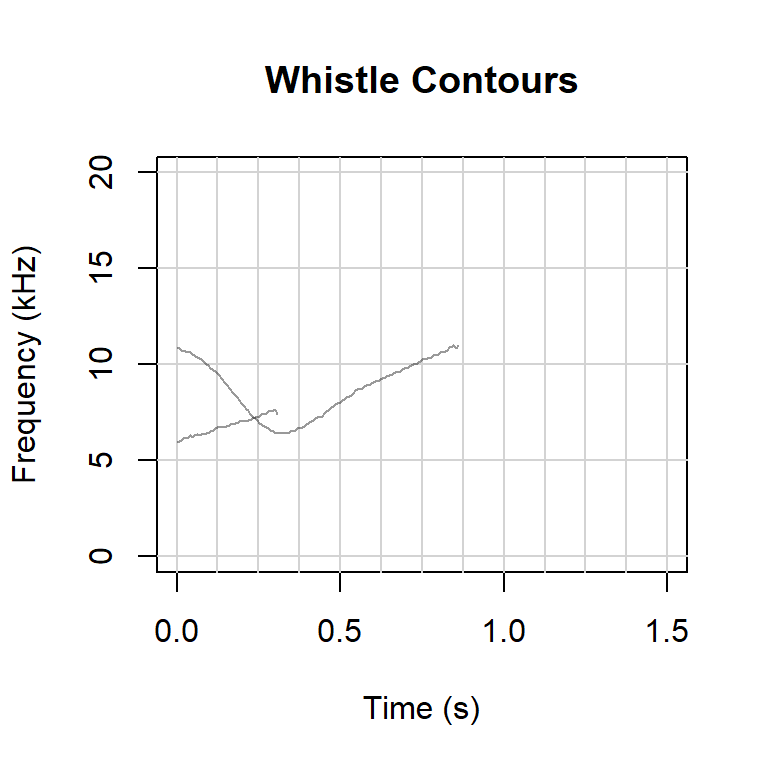

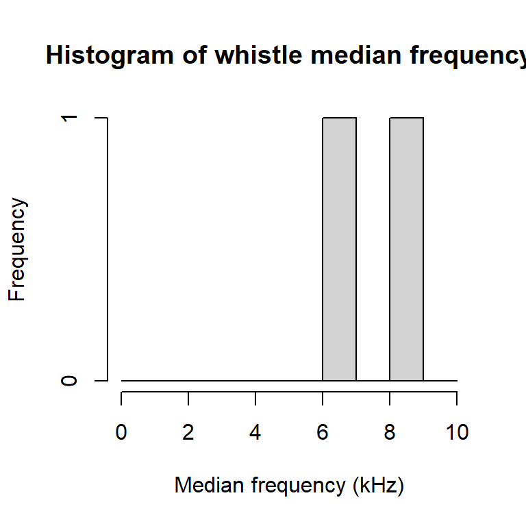

Median statistics for n = 2 whistles.

| parameter | value |
| --- | --- |
| Median begin frequency [kHz] | 8.42 |
| Median end frequency [kHz] | 9.19 |
| Median mean frequency [kHz] (SD) | 7.79 (0.98) |
| Median duration [s] | 0.591 |
| Median frequency range [kHz] (min-max) | 3.15 (6.19 - 9.34) |

#### Event ID: 1705016 | Species: 33

Time: 2017-08-20 18:39UTC to 2017-08-20 20:42UTC

Event contains 49635 original clicks, **6080 valid clicks** after filtering.

Event contains **2274 whistles**.

##### Click plots and table

SNR histogram includes all filtered clicks. Other plots contain only clicks with SNR >= 15 dB (**n = 5836 clicks**) .

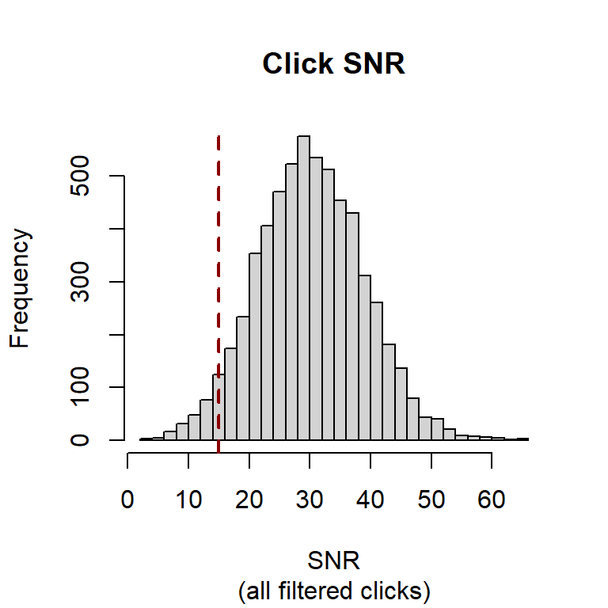

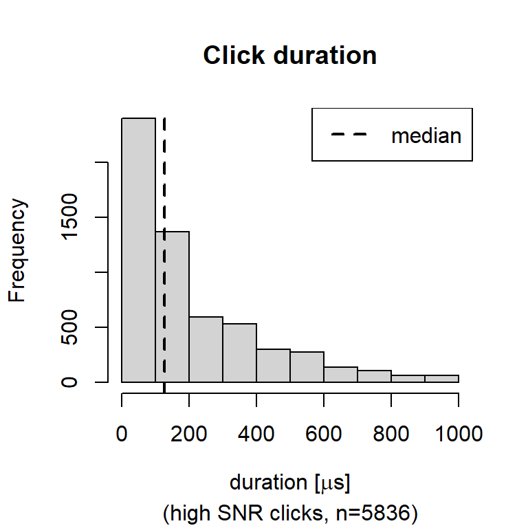

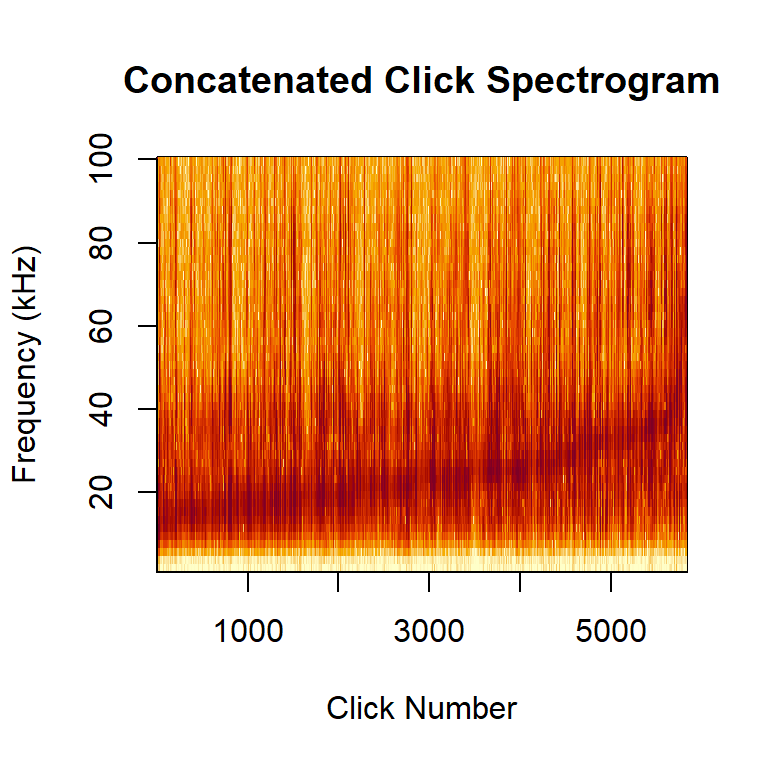

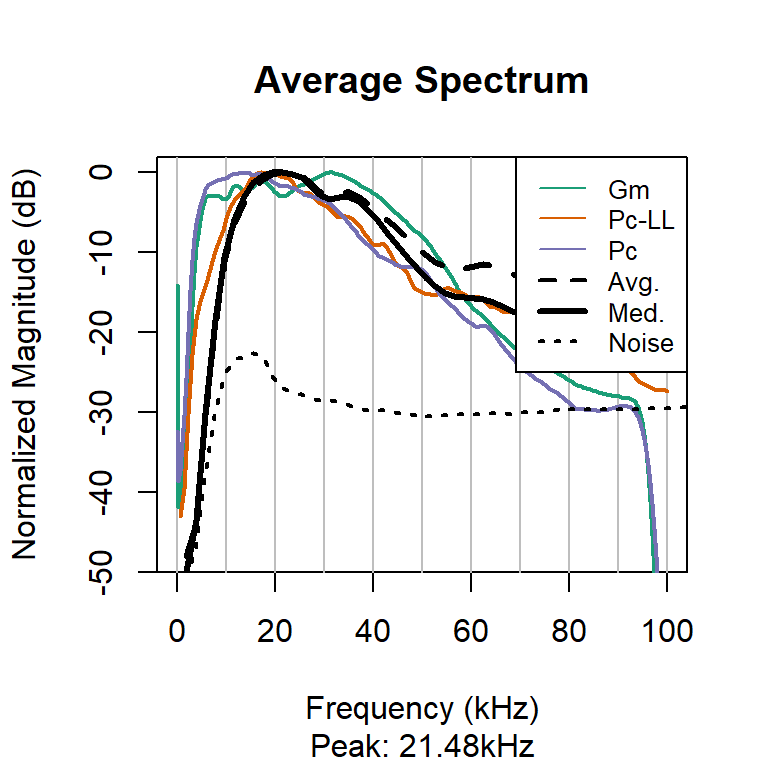

Median statistics for 5836 high SNR clicks with SNR >= 15 dB.

| parameter | value |
| --- | --- |
| Median Peak Frequency [kHz] | 20.4 |
| Median 3dB Center Frequency [kHz] | 20.6 |
| Median 10dB Center Frequency [kHz] | 20.7 |
| Median 3dB Bandwidth [kHz] (lower-upper) | 3.1 (18.2 - 23.1) |
| Median 10dB Bandwidth [kHz] (lower-upper) | 13.1 (12.6 - 27.6) |
| Median duration [μs] (25-75 percentile) | 128 (100 - 304) |

##### Whistle plots and table

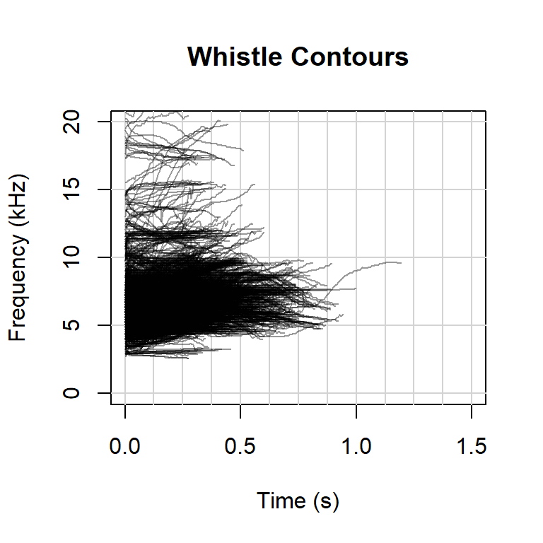

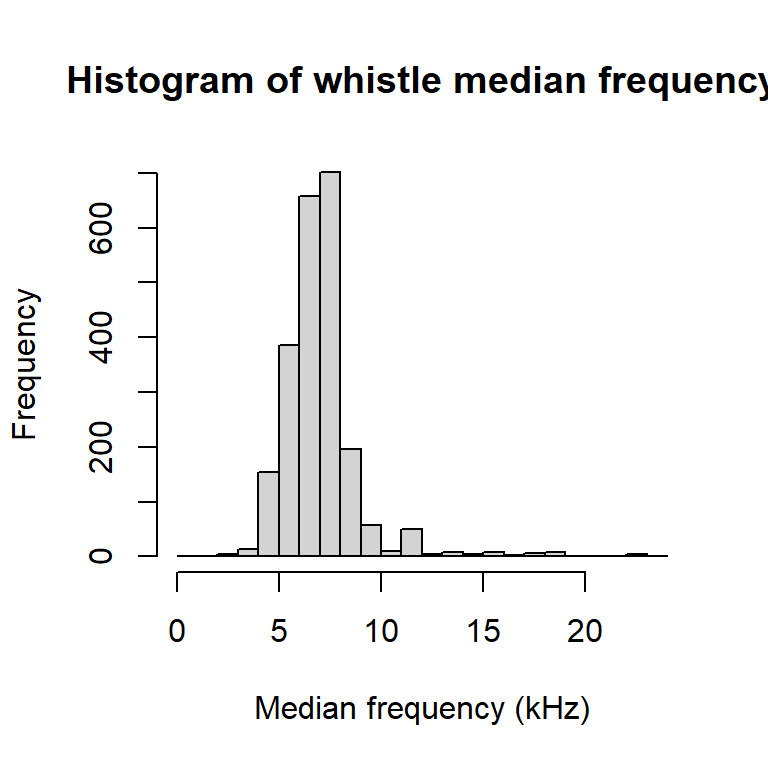

Median statistics for n = 2274 whistles.

| parameter | value |
| --- | --- |
| Median begin frequency [kHz] | 6.37 |
| Median end frequency [kHz] | 7.10 |
| Median mean frequency [kHz] (SD) | 6.87 (0.37) |
| Median duration [s] | 0.375 |
| Median frequency range [kHz] (min-max) | 1.32 (5.86 - 7.54) |

#### Event ID: 1705067 | Species: 33

Time: 2017-08-30 01:46UTC to 2017-08-30 04:26UTC

Event contains 30362 original clicks, **3197 valid clicks** after filtering.

Event contains **2618 whistles**.

##### Click plots and table

SNR histogram includes all filtered clicks. Other plots contain only clicks with SNR >= 15 dB (**n = 3083 clicks**) .

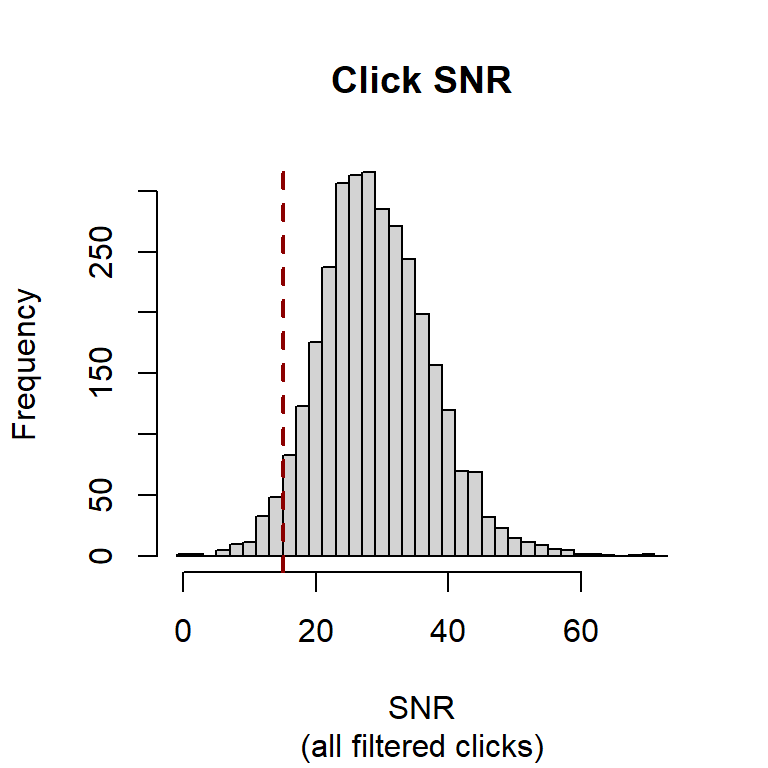

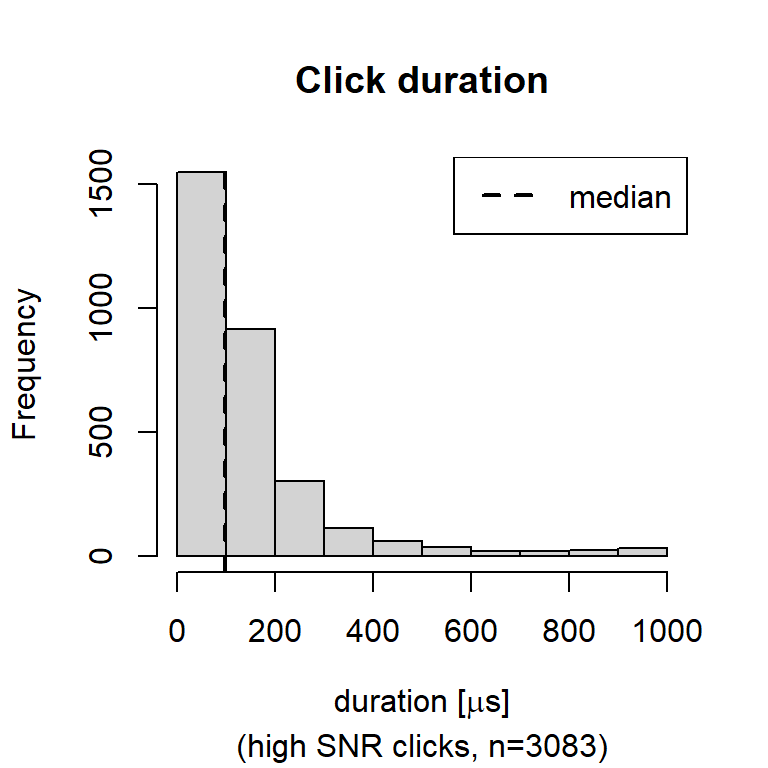

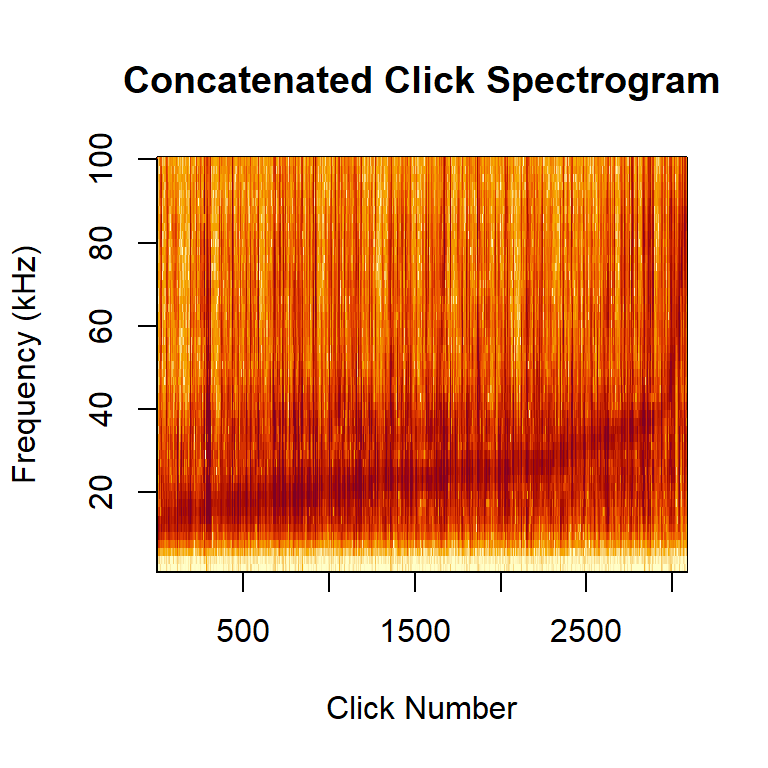

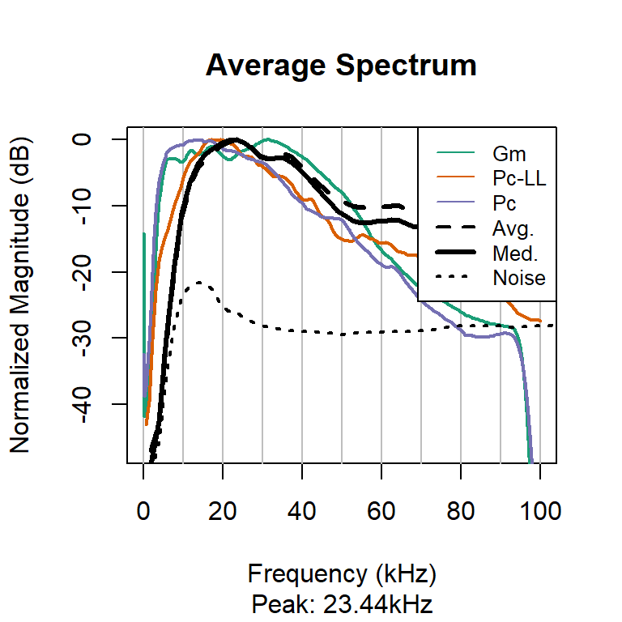

Median statistics for 3083 high SNR clicks with SNR >= 15 dB.

| parameter | value |
| --- | --- |
| Median Peak Frequency [kHz] | 21.2 |
| Median 3dB Center Frequency [kHz] | 21.2 |
| Median 10dB Center Frequency [kHz] | 21.4 |
| Median 3dB Bandwidth [kHz] (lower-upper) | 3.13 (19.3 - 23.2) |
| Median 10dB Bandwidth [kHz] (lower-upper) | 12.3 (13.9 - 27.5) |
| Median duration [μs] (25-75 percentile) | 98 (44 - 172) |

##### Whistle plots and table

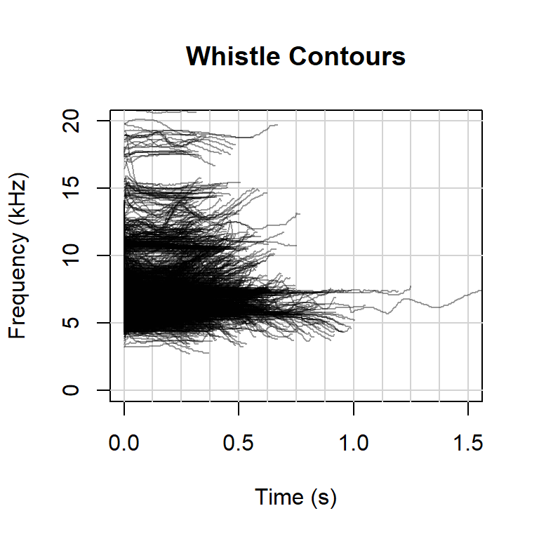

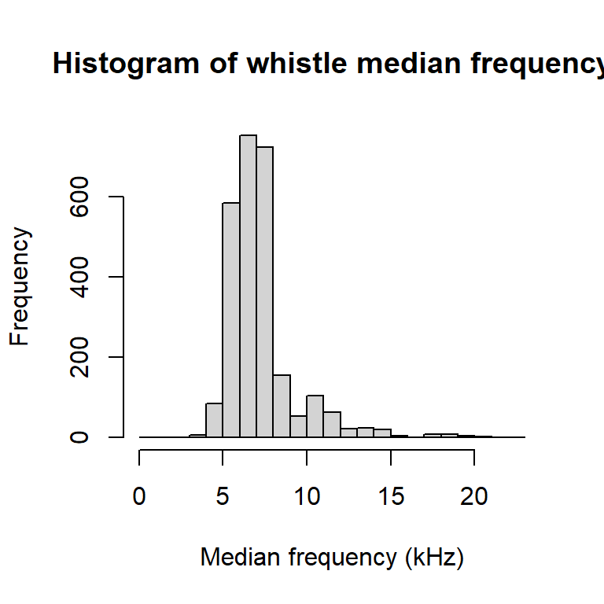

Median statistics for n = 2618 whistles.

| parameter | value |
| --- | --- |
| Median begin frequency [kHz] | 6.81 |
| Median end frequency [kHz] | 7.10 |
| Median mean frequency [kHz] (SD) | 6.83 (0.31) |
| Median duration [s] | 0.355 |
| Median frequency range [kHz] (min-max) | 1.10 (6.15 - 7.54) |

#### Event ID: 1705108 | Species: 33

Time: 2017-09-12 03:22UTC to 2017-09-12 04:46UTC

Event contains 462033 original clicks, **13233 valid clicks** after filtering.

Event contains **237 whistles**.

##### Click plots and table

SNR histogram includes all filtered clicks. Other plots contain only clicks with SNR >= 15 dB (**n = 9059 clicks**) .

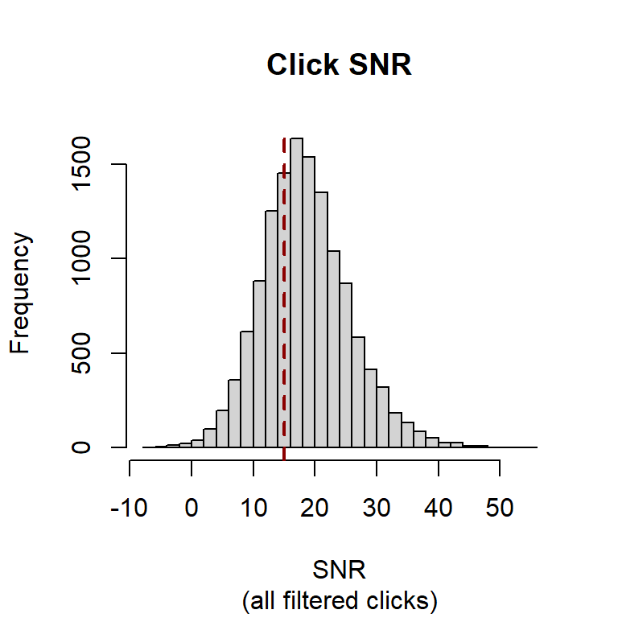

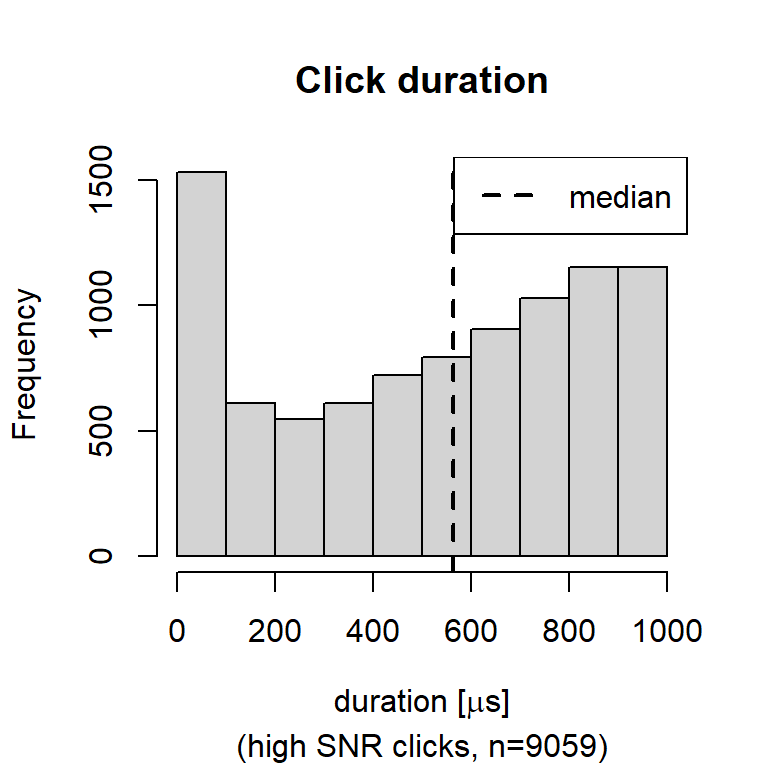

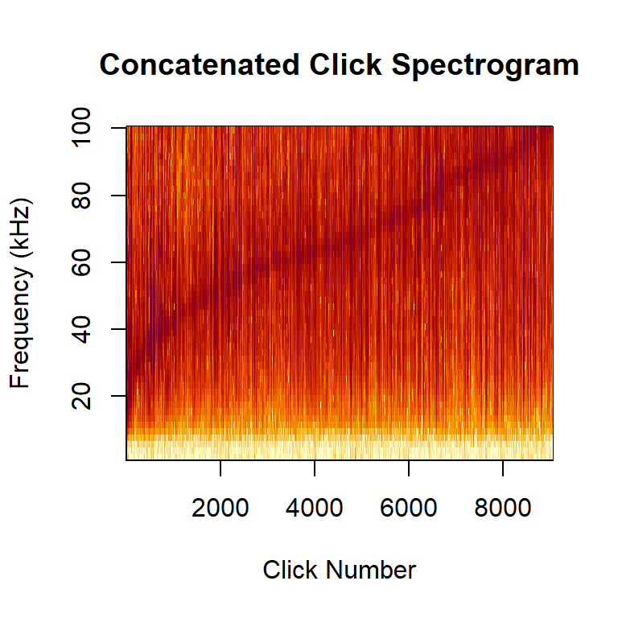

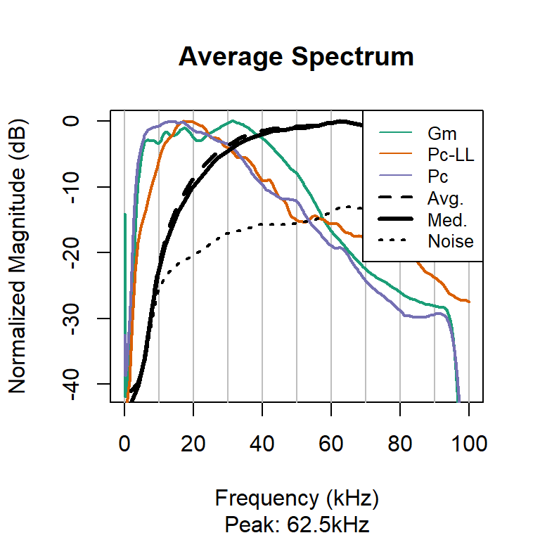

Median statistics for 9059 high SNR clicks with SNR >= 15 dB.

[output not shown]

##### Whistle plots and table

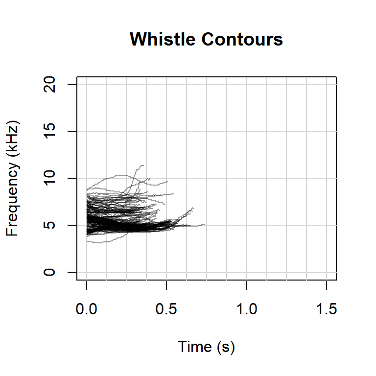

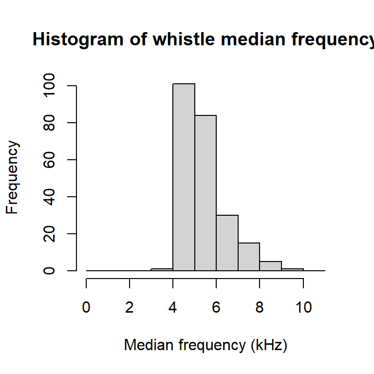

Median statistics for n = 237 whistles.

| parameter | value |
| --- | --- |
| Median begin frequency [kHz] | 5.71 |
| Median end frequency [kHz] | 5.13 |
| Median mean frequency [kHz] (SD) | 5.15 (0.29) |
| Median duration [s] | 0.375 |
| Median frequency range [kHz] (min-max) | 1.03 (4.54 - 5.79) |

#### Event ID: 1705109 | Species: 33

Time: 2017-09-12 16:27UTC to 2017-09-12 18:00UTC

Event contains 25647 original clicks, **1204 valid clicks** after filtering.

Event contains **2136 whistles**.

##### Click plots and table

SNR histogram includes all filtered clicks. Other plots contain only clicks with SNR >= 15 dB (**n = 1154 clicks**) .

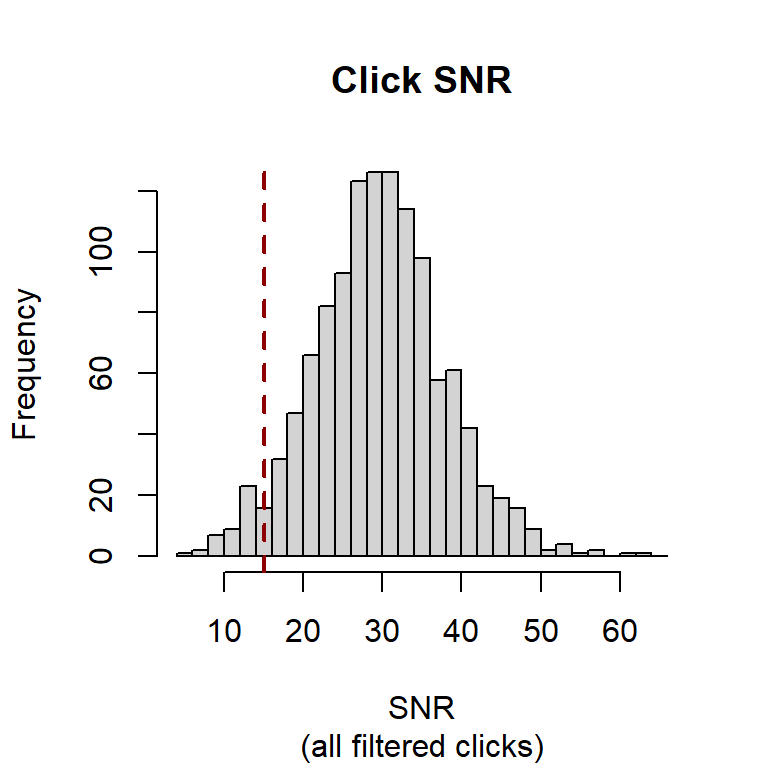

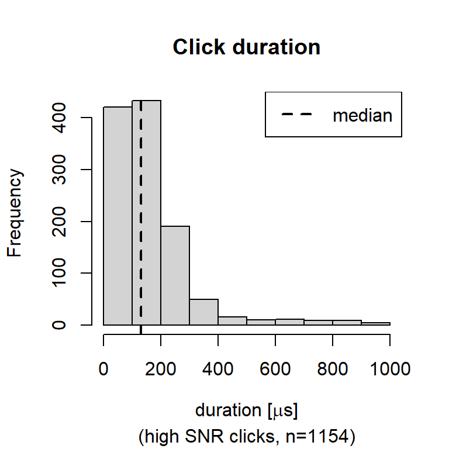

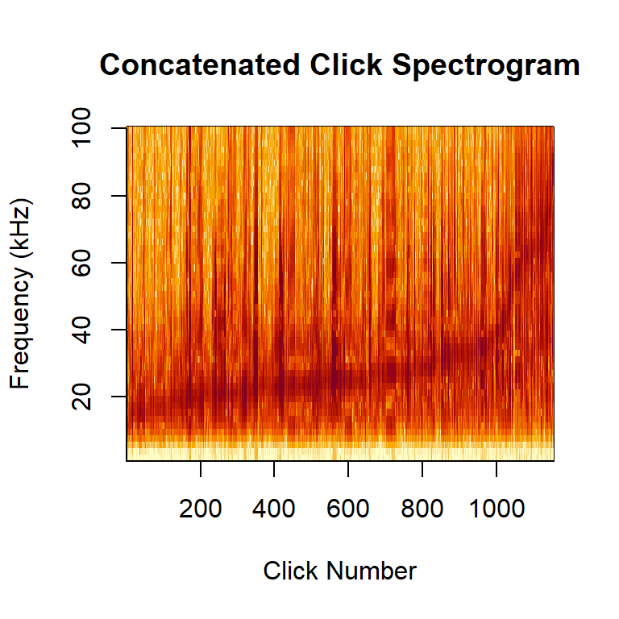

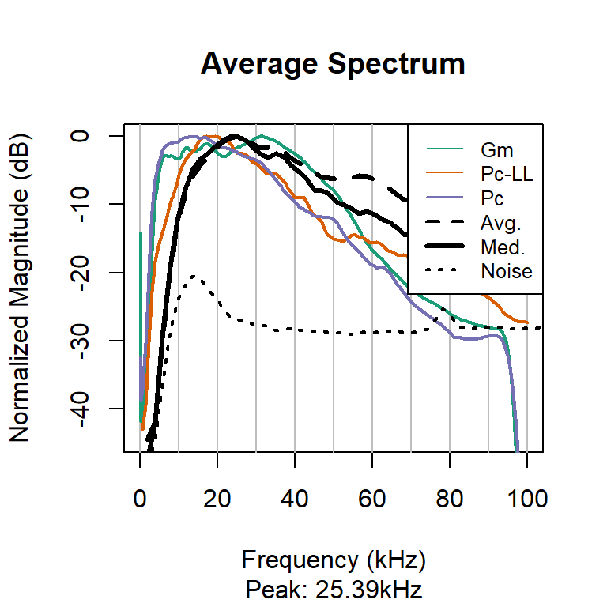

Median statistics for 1154 high SNR clicks with SNR >= 15 dB.

| parameter | value |
| --- | --- |
| Median Peak Frequency [kHz] | 22.8 |
| Median 3dB Center Frequency [kHz] | 22.5 |
| Median 10dB Center Frequency [kHz] | 23.2 |
| Median 3dB Bandwidth [kHz] (lower-upper) | 3.24 (20.9 - 24.4) |
| Median 10dB Bandwidth [kHz] (lower-upper) | 11.7 (16.4 - 29.4) |
| Median duration [μs] (25-75 percentile) | 132 (100 - 202) |

##### Whistle plots and table

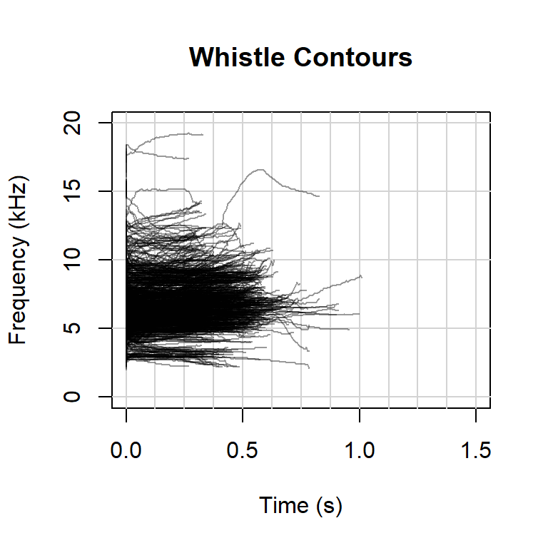

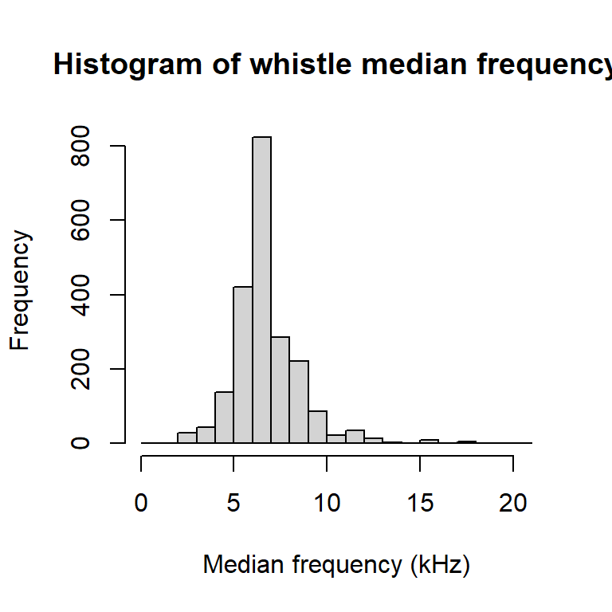

Median statistics for n = 2136 whistles.

| parameter | value |
| --- | --- |
| Median begin frequency [kHz] | 6.23 |
| Median end frequency [kHz] | 6.81 |
| Median mean frequency [kHz] (SD) | 6.58 (0.29) |
| Median duration [s] | 0.307 |
| Median frequency range [kHz] (min-max) | 1.10 (5.86 - 7.25) |